# Introduction to R

08 / 03 / 2018

This is a brief introduction to [R](https://www.r-project.org/). This beautiful document was made using [R Markdown](http://rmarkdown.rstudio.com). If you would like to check the topics around this type of *R Markdown* document, please visit the [R Notebooks](https://rmarkdown.rstudio.com/r_notebooks.html) website.

# Workshop goal

The aim of this study group is to help you get started learning some of the basic tools which will allow you to do data transformation in *R*.

# What will you learn?

We will briefly discuss the essential data structures in base *R*. Then, we are going to focus on the *dplyr* package.

One important point to mention, we will emphasize on **small data**! If you wish to know the basic tools for working with **big data** in *R*, we recommend you to discover the [data.table](https://cran.r-project.org/web/packages/data.table/vignettes/datatable-intro.html) package, for instance.

# Requisites

We need to load and attach some add-on packages to the user’s workspace.

- Note:

  The *R* base package is already loaded and attached to the global environment, by default!

```r
library(dplyr)
library(ggplot2)
library(rmarkdown) # Optional R object!
```

# Data structures

The first section of this introductory *R* course is based on the book [Advanced R](http://adv-r.had.co.nz/), which is authored by [Hadley Wickham](http://hadley.nz/). We encourage anyone interested in *computer science* to explore this insightful referenced material.

## Vectors

The vector is the basic data structure in *R*. A vector has three common properties: **type** (*what is it?*), **length** (*how many elements does it contain?*), and **attributes** (*metadata*). There are two types of vectors in *R*:

- Atomic vectors.
- Lists.

### Atomic vectors

Atomic vectors are *homogeneous* vectors, i.e. all the elements of an atomic vector must have the same type.

We observe four common types of atomic vectors: **character**, **double** *(which is also known as **numeric**)*, **integer**, and **logical**. Additionally, we observe two rare types of atomic vectors: **complex**, and **raw**.

#### Examples

```r
charter <- c("I love R!"); typeof(charter); length(charter)
```

```
[1] "character"
[1] 1
```

```r
do_nu <- c(exp(1), pi) ; typeof(do_nu); length(do_nu)
```

```
[1] "double"
[1] 2
```

```r
inter <- c(-2L, -1L, 0L, 1L, 2L); typeof(inter); length(inter)
```

```
[1] "integer"
[1] 5
```

```r
logia <- c(FALSE, TRUE, F, T); typeof(logia); length(logia)
```

```
[1] "logical"
[1] 4
```

### Lists

Lists are *heterogeneous* vectors, i.e. the elements of a list could have different types. For instance:

```r
extra_students_info <- list(
  Name = c("Adrian", "Asia", "Hugo", "Magdalena"),
  Age = c(21, 23, 25, 22, 50),
  `Do you love R?` = c(TRUE, TRUE, TRUE, FALSE),
  Year = c(0L, 1L, 2L, 3L, 1L)
)
typeof(extra_students_info)
```

```
[1] "list"
```

```r
length(extra_students_info)
```

```
[1] 4
```

## Attributes

### What is metadata?

[Metadata](https://en.oxforddictionaries.com/definition/metadata) is a set of data which describes and gives information about a set of data.

In summary, the following three items are the most important attributes in *R*:

- Names.

```r
names(charter); names(charter) <- c("Emotion")
```

```r
names(do_nu); names(do_nu) <- c("Euler", "Pi")
```

```r
names(inter); names(inter) <- c("Minus Two", "Minus One", "Zero", "One", "Two")
```

```r
names(logia); names(logia) <- c("False!", "True!", "False!", "True!")
```

```r
names(extra_students_info)
```

```
[1] "Name"           "Age"            "Do you love R?" "Year"
```

- Dimensions.

```r
?dim
help("dim")
```

- Class.

```r
?class
help("class")
```

## Matrices and arrays

Now, we will consider the multi-dimensional atomic vectors.

```r
mix <- matrix(1:32, nrow = 8, ncol = 4)
a_ray <- array(1:32, dim = c(4, 2, 4))
```

## Data frames

A data frame is basically a list which is composed of fixed-length atomic vectors.

```r
students_info <- data.frame(stringsAsFactors = FALSE,
  Name = c("Adrian", "Asia", "Hugo", "Magdalena"),
  Age = c(21, 23, 25, 22),
  `Do you love R?` = c(TRUE, TRUE, TRUE, FALSE),
  Year = c(1L, 2L, 3L, 1L),
  City = c("Katowice", "Cracovia", "Warszawa", "Zakopane")
)
print(students_info)
```

| Name | Age | Do.you.love.R. | Year | City |
| --- | --- | --- | --- | --- |
| Adrian | 21 | TRUE | 1 | Katowice |
| Asia | 23 | TRUE | 2 | Cracovia |
| Hugo | 25 | TRUE | 3 | Warszawa |
| Magdalena | 22 | FALSE | 1 | Zakopane |

```r
rownames(students_info)
```

```
[1] "1" "2" "3" "4"
```

```r
colnames(students_info) # names(students_info)
```

```
[1] "Name"           "Age"            "Do.you.love.R." "Year"           "City"
```

```r
nrow(students_info)
```

```
[1] 4
```

```r
ncol(students_info) # length(students_info)
```

```
[1] 5
```

```r
dim(students_info)
```

```
[1] 4 5
```

# Data transformation

The last section of this introductory *R* course is based on the book [R for Data Science](http://r4ds.had.co.nz/), which is authored by [Garrett Grolemund](https://github.com/garrettgman) and [Hadley Wickham](http://hadley.nz/). We encourage anyone interested in *data science* to explore this insightful referenced material.

- Requisites

  We will use the database included in the *nycflights13* package.

```r
library(nycflights13)
View(flights)
```

## The `dplyr` package

We will defy our data transformation challenges in *R* using five key `dplyr` functions: `filter()`, `arrange()`, `select()`, `mutate()`, and `summarise()` (*which is also called `summarize()`*). All of these items can be used together with `group_by()`, which is another key `dplyr` function.

The previuosly mentioned key `dplyr` functions form the set of *“verbs for a language of data manipulation”*, in words of [Hadley Wickham](http://hadley.nz/).

All verbs work as follows:

- The first function argument is a data frame.
- The successive function arguments describe the way in which we will manipulate the input data frame by using the input data frame variable names.
- The output data frame is the result of the input data frame manipulation/transformation.

### Verb `filter()`

#### Example

```r
fe_se <- filter(flights, month == 2, day == 2) # Find the flights scheduled for February 2.
```

#### Practice

```r
# (A) Filter the data frame "flights" by the following months of departure: October, and November.
octo_nob <- filter(flights, month %in% c(10, 11))
# (B) The data frame "flights" should not include the following months of departure: March, April, and December.
no_mar_ap_deb <- filter(flights, !(month %in% c(3, 4, 12)))
# (C) Filter the data frame "flights" by arrival delay greater than 90 minutes.
ar_del_90_plus_min <- filter(flights, arr_delay > 90)
```

### Verb `arrange()`

#### Example

```r
ye_mo_da_as <- arrange(flights, year, month, day) # Order the data frame "flights" by year, month and day. Ascending order.
ye_mo_da_de <- arrange(flights, desc(year), desc(month), desc(day)) # Order the data frame "flights" by year, month and day. Descending order.
```

#### Practice

```r
# (A) Find the ten most delayed flights.
most_del <- arrange(flights, desc(arr_delay))
# (B) Find the ten fastest flights.
fast <- arrange(flights, air_time)
```

### Verb `select()`

#### Example

```r
ye_mo_da <- select(flights, year, month, day) # Extract from the data frame "flights" the following variables: year, month, day.
```

#### Practice

```r
# (A) Select "origin"" and "destination".
in_org_den <- select(flights, origin, dest)
# (B) Exclude "air_time" and "distance".
ex_airt_dis <- select(flights, -(air_time & distance))
```

### Verb `mutate()`

#### Example

```r
total_delay <- mutate(flights, total_delay = dep_delay + arr_delay) # Create a new variable called "total_delay", which stands for the sum of departure delay and arrival delay.
?dplyr::transmute
```

#### Practice

```r
# (A) Speed (kph).
speed_kph <- mutate(flights, speed = distance/air_time*60)
```

### Verb `summarise()`

#### Example

```r
me_dep_del <- summarise(flights, me_dep_del = mean(dep_delay, na.rm = TRUE)) # Calculate the mean value of all the departure delays.
```

#### Practice

```r
# (A) Obtain the max flight distance.
max_dis <- summarise(flights, max_dis = max(distance, na.rm = TRUE))
```

### Verb `groub_by()`

#### Example

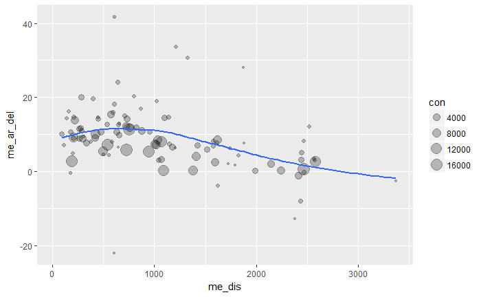

```r
via_den <- group_by(flights, dest) # We will group the data frame "flights" by destination.
ar_del_via_den <- # We will create a new data frame which contains the following items: the number of flights, the mean value of the distances, and the mean value of the arrival delays.
  summarise(via_den,
    con = n(),
    me_dis = mean(distance, na.rm = TRUE),
    me_ar_del = mean(arr_delay, na.rm = TRUE)
  )
ggplot(data = filter(ar_del_via_den, me_dis < max(me_dis)), mapping = aes(x = me_dis, y = me_ar_del)) + # We will plot the new data frame, except for the largest mean value of the distances.
  geom_point(aes(size = con), alpha = 1/4) +
  geom_smooth(se = FALSE)
```

#### Practice

```r
# (A) Group by month of departure, count the number of flights, and determine the shortest distance.
via_mo <- group_by(flights, month)
short_dist <- summarise(via_mo, con = n(), min_dis = min(distance, na.rm = TRUE))
```

### The pipe operator (`%>%`) in *R*

#### Example

```r
ar_del_via_den <- # We will repeat the "group_by()" example, but we will use the pipe operator (%>%) for simplifying the programming syntax.
  flights %>%
  group_by(dest) %>%
  summarise(con = n(), me_dis = mean(distance, na.rm = TRUE), me_ar_del = mean(arr_delay, na.rm = TRUE))
```

#### Practice

```r
# (A) Select "flight", "air_time" and "distance". Filter NAs from "air_time" and "distance". Create a new variable which captures the trip speed (kph) for each "flight" element. Group by "flight". Find the fastest trip speed for each "flight" element. Extract the top ten fastest trip speeds.
top_ten_fast_flight_id <-
  flights %>%
  select(flight, air_time, distance) %>%
  filter(!is.na(air_time), !is.na(distance)) %>%
  mutate(speed = distance/air_time*60) %>%
  group_by(flight) %>%
  summarise(fast = max(speed)) %>%
  arrange(desc(fast)) %>%
  slice(1:10) %>%
  View()
```

# Thanks a lot!

#### Document created by Michael Alexander!